# Biodiversity in National Parks

GSD

2017-08-15

# 1 Loading required libraries,

```r
library(tidyverse)
library(knitr)
library(data.table)
library(formattable)
parks=read.csv("parks.csv",header=TRUE,stringsAsFactors = FALSE)
species=read.csv("species.csv",header=TRUE,stringsAsFactors = FALSE)
glimpse(parks)
```

```
## Observations: 56
## Variables: 6
## $ Park.Code <chr> "ACAD", "ARCH", "BADL", "BIBE", "BISC", "BLCA", "BRC...
## $ Park.Name <chr> "Acadia National Park", "Arches National Park", "Bad...
## $ State     <chr> "ME", "UT", "SD", "TX", "FL", "CO", "UT", "UT", "UT"...
## $ Acres     <int> 47390, 76519, 242756, 801163, 172924, 32950, 35835, ...
## $ Latitude  <dbl> 44.35, 38.68, 43.75, 29.25, 25.65, 38.57, 37.57, 38....
## $ Longitude <dbl> -68.21, -109.57, -102.50, -103.25, -80.08, -107.72, ...
```

```r
glimpse(species)
```

```
## Observations: 119,248
## Variables: 14
## $ Species.ID          <chr> "ACAD-1000", "ACAD-1001", "ACAD-1002", "AC...
## $ Park.Name           <chr> "Acadia National Park", "Acadia National P...
## $ Category            <chr> "Mammal", "Mammal", "Mammal", "Mammal", "M...
## $ Order               <chr> "Artiodactyla", "Artiodactyla", "Carnivora...
## $ Family              <chr> "Cervidae", "Cervidae", "Canidae", "Canida...
## $ Scientific.Name     <chr> "Alces alces", "Odocoileus virginianus", "...
## $ Common.Names        <chr> "Moose", "Northern White-Tailed Deer, Virg...
## $ Record.Status       <chr> "Approved", "Approved", "Approved", "Appro...
## $ Occurrence          <chr> "Present", "Present", "Present", "Not Conf...
## $ Nativeness          <chr> "Native", "Native", "Not Native", "Native"...
## $ Abundance           <chr> "Rare", "Abundant", "Common", "", "Common"...
## $ Seasonality         <chr> "Resident", "", "", "", "Breeder", "", "Va...
## $ Conservation.Status <chr> "", "", "Species of Concern", "Endangered"...
## $ X                   <chr> "", "", "", "", "", "", "", "", "", "", ""...
```

# 2 List of parks by acres

There are 56 parks.

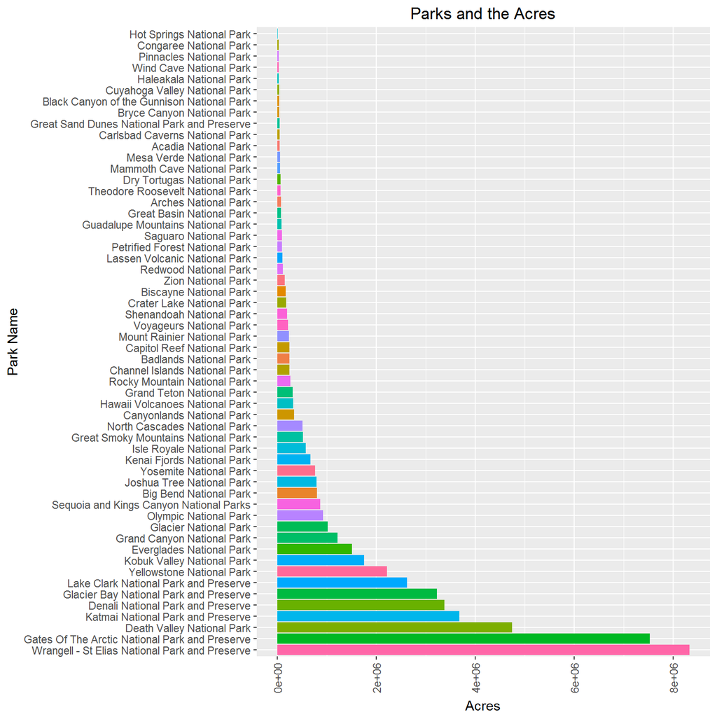

```r
parks %>% arrange(-Acres) %>% ggplot(aes(factor(Park.Name,levels=Park.Name),Acres,fill=Park.Name))+geom_bar(stat="identity")+theme(axis.text.x = element_text(angle=90,vjust=0.5),plot.title=element_text(family="verdana",hjust=0.5),legend.position = "none")+labs(x="Park Name",y="Acres")+ggtitle("Parks and the Acres")+coord_flip()
```

# 3 Count of each category,Abundance level,Nativity,Family,Parks with highest species count,Conservation status,Seasonality

## 3.1 By Category

There are 14 categories in total.

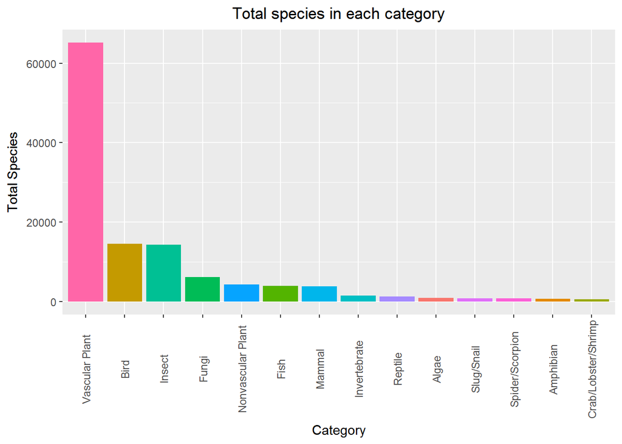

```r
temp=species %>% group_by(Category) %>% summarise(Category.Count=n()) %>% arrange(-Category.Count)
ggplot(temp,aes(factor(Category,levels=Category),Category.Count,fill=Category))+geom_bar(stat="identity")+theme(axis.text.x = element_text(angle=90,vjust=0.5),plot.title=element_text(family="verdana",hjust=0.5),legend.position = "none")+labs(x="Category",y="Total Species")+ggtitle("Total species in each category")
```

## 3.2 By Abundance level

```r
length(unique(species$Abundance))
```

```
## [1] 9
```

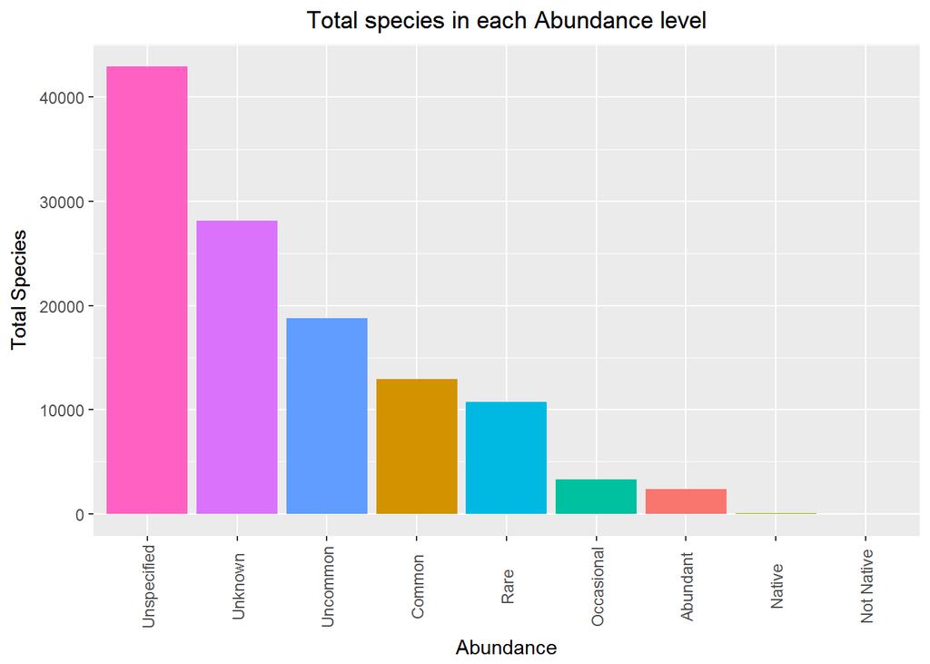

```r
temp=species %>% group_by(Abundance) %>% summarise(Abundance.Count=n()) %>% arrange(-Abundance.Count)
temp[temp$Abundance=="",1]="Unspecified"
ggplot(temp,aes(factor(Abundance,levels=Abundance),Abundance.Count,fill=Abundance))+geom_bar(stat="identity")+theme(axis.text.x = element_text(angle=90,vjust=0.5),plot.title=element_text(family = "Verdana",hjust=0.5),legend.position = "none")+labs(x="Abundance",y="Total Species")+ggtitle("Total species in each Abundance level")
```

As seen from the bar chart,most of the category of species are not recorded into abundance level and it is impossible to draw conclusions about the abundance level of each species.

## 3.3 Nativity:

```r
length(unique(species$Nativeness))
```

```
## [1] 6
```

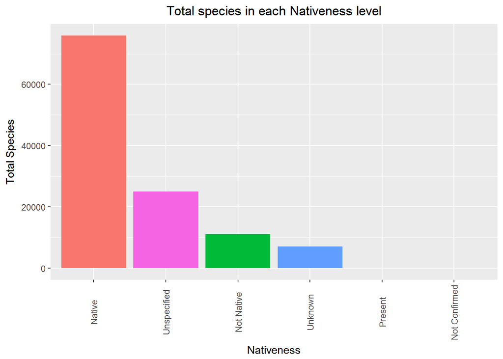

```r
temp=species %>% group_by(Nativeness) %>% summarise(Nativeness.Count=n()) %>% arrange(-Nativeness.Count)
temp[temp$Nativeness=="",1]="Unspecified"
ggplot(temp,aes(factor(Nativeness,levels=Nativeness),Nativeness.Count,fill=Nativeness))+geom_bar(stat="identity")+theme(axis.text.x = element_text(angle=90,vjust=0.5),plot.title=element_text(family = "Verdana",hjust=0.5),legend.position = "none")+labs(x="Nativeness",y="Total Species")+ggtitle("Total species in each Nativeness level")
```

Native species are found in abundance in the parks with over 65000 species comming under them.There are about more than 11,000 non native species.

## 3.4 Family

```r
length(unique(species$Family))
```

```
## [1] 2333
```

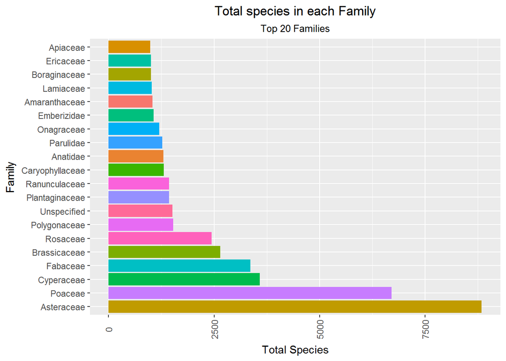

```r
temp=species %>% group_by(Family) %>% summarise(Family.Count=n()) %>% arrange(-Family.Count)
temp[temp$Family=="",1]="Unspecified"
ggplot(head(temp,20),aes(factor(Family,levels=Family),Family.Count,fill=Family))+geom_bar(stat="identity")+theme(axis.text.x = element_text(angle=90,vjust=0.5),plot.title=element_text(family = "Verdana",hjust=0.5),legend.position = "none",plot.subtitle=element_text(hjust=0.5))+labs(x="Family",y="Total Species")+ggtitle("Total species in each Family",subtitle = "Top 20 Families")+coord_flip()
```

## 3.5 Conservation Status

```r
length(unique(species$Conservation.Status))
```

```
## [1] 12
```

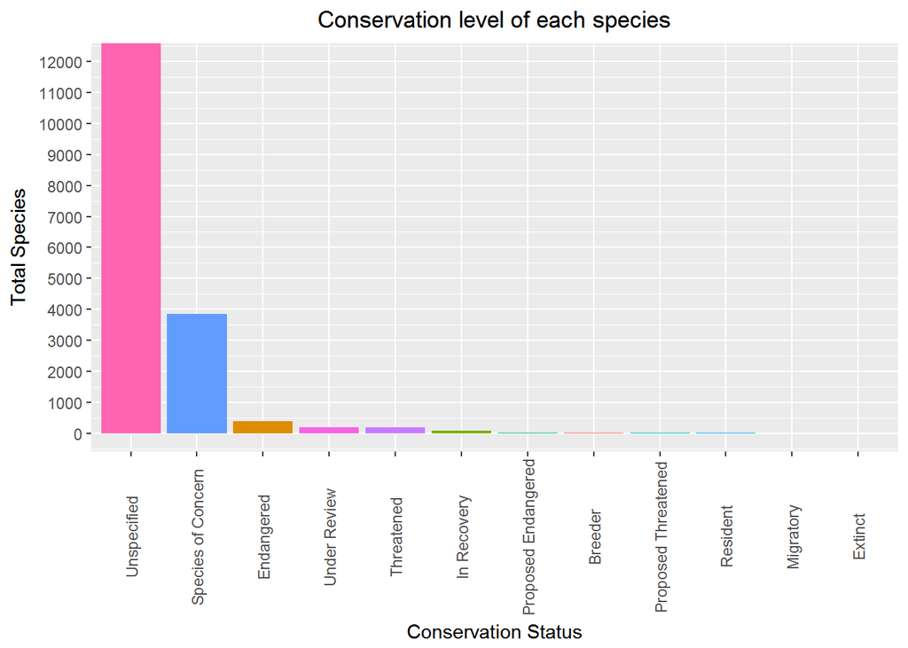

```r
temp=species %>% group_by(Conservation.Status) %>% summarise(Count=n()) %>% arrange(-Count)
temp[temp$Conservation.Status=="",1]="Unspecified"
ggplot(temp,aes(factor(Conservation.Status,levels=Conservation.Status),Count,fill=Conservation.Status))+geom_bar(stat="identity")+theme(axis.text.x = element_text(angle=90,vjust=0.5),plot.title=element_text(family = "Verdana",hjust=0.5),legend.position = "none",plot.subtitle=element_text(hjust=0.5))+labs(x="Conservation Status",y="Total Species")+ggtitle("Conservation level of each species")+coord_cartesian(ylim=c(0,12000),expand=TRUE)+scale_y_continuous(breaks=seq(0,12000,1000))
```

Most of the species are categoried as unspecified .Above 3000 species are species of concern while less than 500 of them are endangered.

Now,let us examine in depth,

# 4 Which category of species is found in abundance?

In total there are 56 parks as evident from the parks data.

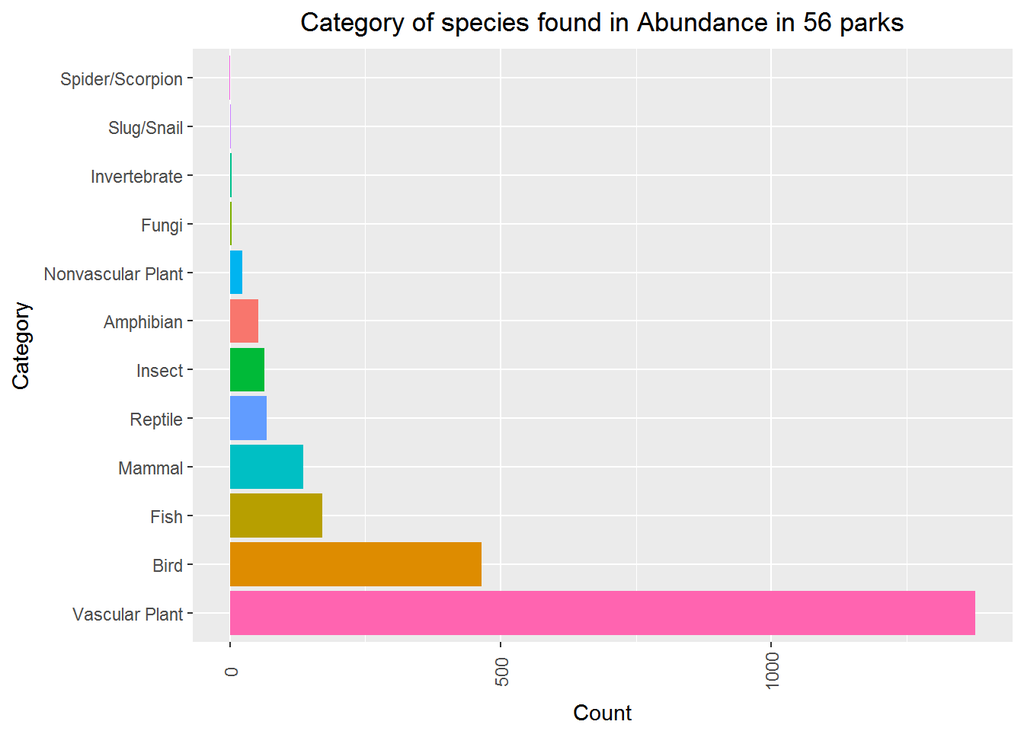

```r
species %>% filter(Abundance=="Abundant") %>% group_by(Category) %>% summarise(abundance.count=n()) %>% arrange(-abundance.count) %>% ggplot(aes(factor(Category,levels=Category),abundance.count,fill=Category))+geom_bar(stat="identity")+theme(axis.text.x = element_text(angle=90,vjust=0.5),plot.title=element_text(family="verdana",hjust=0.5),legend.position = "none")+labs(x="Category",y="Count")+ggtitle("Category of species found in Abundance in 56 parks")+coord_flip()
```

# 5 Which category of species is endangered?

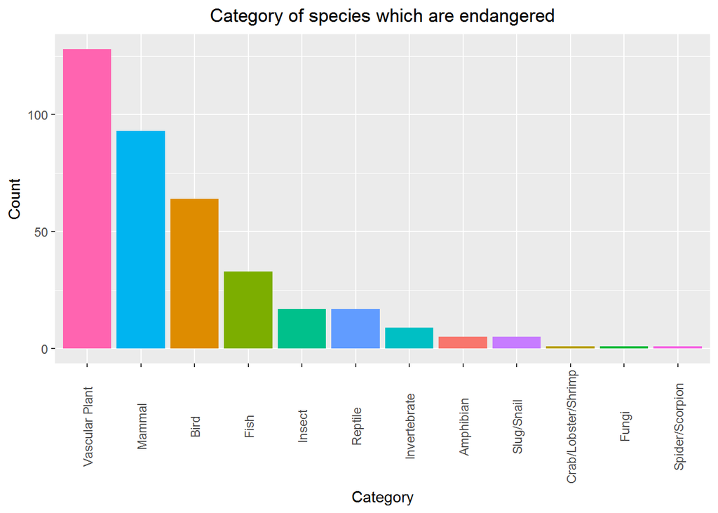

```r
temp=species %>% filter(Conservation.Status=="Endangered") %>% group_by(Category) %>% summarise(count=n()) %>% arrange(-count)
ggplot(temp,aes(factor(Category,levels=Category),count,fill=Category))+geom_bar(stat="identity")+theme(axis.text.x = element_text(angle=90,vjust=0.5),plot.title=element_text(family="verdana",hjust=0.5),legend.position = "none")+labs(x="Category",y="Count")+ggtitle("Category of species which are endangered")
```

Vascular plants are endangered the most followed by Mammals.

# 6 Which park has maximum Vascular plants?

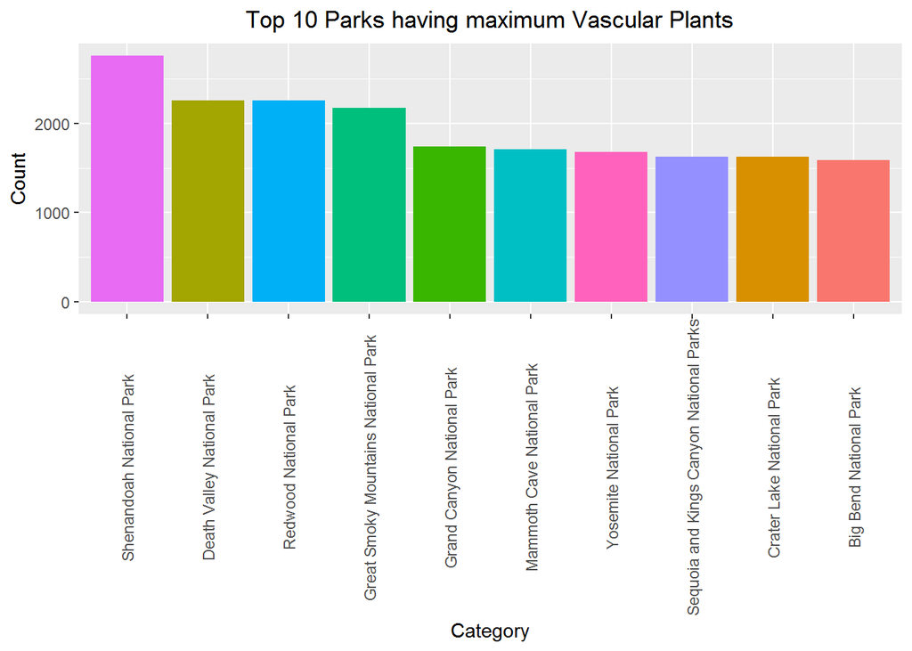

```r
temp=species %>% filter(Category=="Vascular Plant") %>% group_by(Park.Name) %>% summarise(count=n()) %>% arrange(-count)
ggplot(head(temp,10),aes(factor(Park.Name,levels=Park.Name),count,fill=Park.Name))+geom_bar(stat="identity")+theme(axis.text.x = element_text(angle=90,vjust=0.5),plot.title=element_text(family="verdana",hjust=0.5),legend.position = "none")+labs(x="Category",y="Count")+ggtitle("Top 10 Parks having maximum Vascular Plants")
```

*Shenandoah National Park,Death Valley National Park,Redwood National Park,Great Smoky Mountains National Park* has more than 2000 Vascular plants.

# 7 Which park has maximum endagered Vascular plants ?

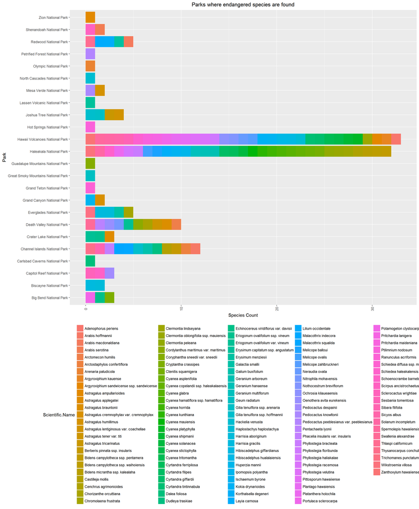

```r
temp=species %>% filter((Conservation.Status=="Endangered") & (Category=="Vascular Plant"))
ggplot(temp,aes(Park.Name,fill=Scientific.Name))+geom_bar(stat="count")+theme(axis.text.x = element_text(angle=90,vjust=0.5),plot.title=element_text(family="verdana",hjust=0.5),legend.position = "bottom")+labs(x="Park",y="Species Count")+ggtitle("Parks where endangered species are found")+coord_flip()
```

*Hawaii Volcanoes National Park ,Haleakala National Park , Channel Island National Park ,Death Valley National Park* has maximum number of endangered vascular plants.

# 8 Which species is found in most parks?

```r
temp=species %>% group_by(Common.Names) %>% summarise(Count=n()) %>% arrange(-Count)
temp[temp$Common.Names=="None",1:2]=NA
temp=na.omit(temp)
summary(temp)
```

```
##  Common.Names           Count
##  Length:35825       Min.   : 1.000
##  Class :character   1st Qu.: 1.000
##  Mode  :character   Median : 1.000
##                     Mean   : 2.571
##                     3rd Qu.: 2.000
##                     Max.   :75.000
```

Here 75 % of the species are found in less than 5 parks.Therefore each park has distinct species of its own.